# Fungicide Profitability for Soybean Rust Management in Brazil: A Stochastic Simulation Approach

Kaique Alves

# Packages

```r
library(tidyverse)
library(gsheet)
library(cowplot)
library(ggthemes)
library(DescTools)
library(minpack.lm)
library(agricolae)
library(readxl)
library(ggridges)
```

# Severity

## Import data

Importing data of soybean rust severity (SBR)

```r
sev_data = read.csv("sev_data.csv")
head(sev_data)
```

```
##   trial severity     mse active_ingredient year spray   location state
## 1   202      0.1 9.90909         trif_prot 2012     2      MAFRA    SC
## 2     3      0.1 6.53177         azox_cypr 2005     2    UBERABA    MG
## 3     3      0.1 6.53177              tebu 2005     2    UBERABA    MG
## 4     8      0.1 0.34482         azox_cypr 2005     2 GUARAPUAVA    PR
## 5     7      0.1 6.41161              tebu 2005     2    IPAMERI    GO
## 6     7      0.1 6.41161         azox_cypr 2005     2    IPAMERI    GO
```

Filtering only values of severity in the cheack treatment

```r
sev_check = sev_data %>%
  filter(active_ingredient == "check")
head(sev_check)
```

```
##   trial severity    mse active_ingredient year spray
## 1   152      0.4 0.0076             check 2010     2
## 2    33      0.5 0.0271             check 2006     2
## 3    85      1.3 0.0409             check 2008     2
## 4     4      5.0 0.0282             check 2005     2
## 5   210      5.5 2.3139             check 2013     2
## 6   218      5.8 0.7697             check 2013     2
##                     location state
## 1 SANTO ANTÃ”NIO DA PATRULHA    RS
## 2                PASSO FUNDO    RS
## 3                    UBERABA    MG
## 4                  MARACAJÃš    MS
## 5      SÃƒO GABRIEL DO OESTE    MS
## 6                   DOURADOS    MS
```

## Empirical distribution

Severity distribution

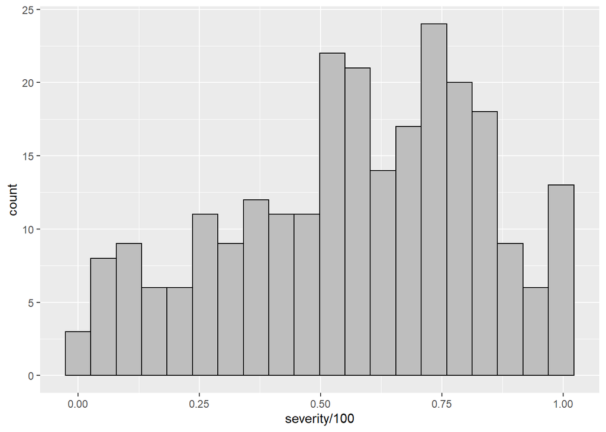

```r
sev_check %>%
  ggplot(aes(severity/100))+
geom_histogram(bins = 20, color = "black", fill = "gray")
```

## Modeling

Modeling severity cumulative density to beta cumulative density

```r
sev = sev_check$severity

Fx= environment(ecdf(sev))$y
x = environment(ecdf(sev))$x/100

summary(nlsLM(Fx ~ pbeta(x, shape1, shape2, log = FALSE) ,
      start = c(shape1 = 1, shape2 = 1),
      control = nls.lm.control(maxiter = 100000)))
```

```
##
## Formula: Fx ~ pbeta(x, shape1, shape2, log = FALSE)
##
## Parameters:
##        Estimate Std. Error t value Pr(>|t|)
## shape1  1.70736    0.02761   61.83   <2e-16 ***
## shape2  1.26581    0.01925   65.75   <2e-16 ***
## ---
## Signif. codes:  0 '***' 0.001 '**' 0.01 '*' 0.05 '.' 0.1 ' ' 1
##
## Residual standard error: 0.02053 on 186 degrees of freedom
##
## Number of iterations to convergence: 6
## Achieved convergence tolerance: 1.49e-08
```

## Visualization

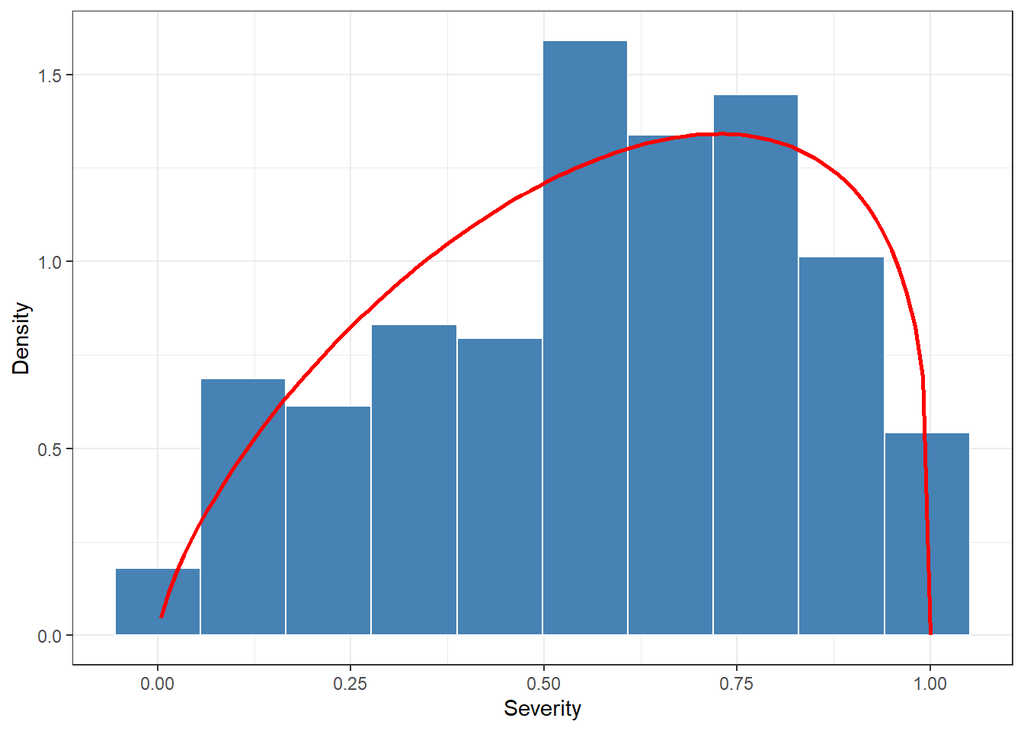

```r
sev_dist_plot = sev_check %>%
  ggplot(aes(severity/100))+
 geom_histogram(aes(y = ..density..),bins = 10, color = "white", fill = "Steelblue")+
   stat_function(fun=function(x) dbeta(x, 1.707, 1.266), color= "red", size = 1)+
  theme_bw()+
  labs(x="Severity", y = "Density")
sev_dist_plot
```

```r
ggsave("figs/sev_dist.png", dpi=600, height = 3, width = 4)
```

# Soybean price

## Import data

```r
soybean = gsheet2tbl("https://docs.google.com/spreadsheets/d/1-jQ9OgWdLQCb0iB0FqbrhuVi7LiNhqxvf9QU4-iuc3o/edit#gid=1085329359")
head(soybean)
```

```
## # A tibble: 6 x 5
##   state month  year price national_price
##   <chr> <dbl> <dbl> <dbl>          <dbl>
## 1 GO       10  2019  78.3           77.0
## 2 GO        9  2019  77.4           75.8
## 3 GO        8  2019  73.0           71.6
## 4 GO        7  2019  68.1           68.4
## 5 GO        6  2019  69.7           70.1
## 6 GO        5  2019  67.2           66.2
```

conversion to US dollar

```r
sbr_price = soybean %>%
  filter(year>=2015) %>%
  mutate(price = (price/60)/4,
         national_price = (national_price/60)/4)
sbr_price
```

```
## # A tibble: 290 x 5
##    state month  year price national_price
##    <chr> <dbl> <dbl> <dbl>          <dbl>
##  1 GO       10  2019 0.326          0.321
##  2 GO        9  2019 0.322          0.316
##  3 GO        8  2019 0.304          0.298
##  4 GO        7  2019 0.284          0.285
##  5 GO        6  2019 0.291          0.292
##  6 GO        5  2019 0.280          0.276
##  7 GO        4  2019 0.282          0.282
##  8 GO        3  2019 0.283          0.288
##  9 GO        2  2019 0.278          0.282
## 10 GO        1  2019 0.301          0.289
## # ... with 280 more rows
```

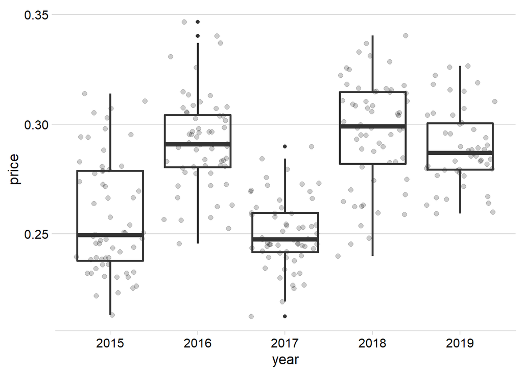

```r
sbr_price %>%
  ggplot(aes(year,price)) +
  geom_jitter(alpha =.2, size =2)+
  geom_boxplot(aes(group = year), fill = NA, size= 1)+
  scale_color_gradient()+
  theme_minimal_hgrid()
```

```r
  # facet_wrap(~state)
```

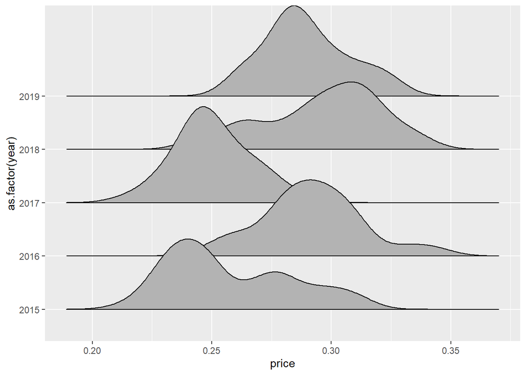

```r
sbr_price %>%
  ggplot(aes(y = as.factor(year),price)) +
  geom_density_ridges2()
```

Mean and Standad deviantion

```r
mean(sbr_price$price)
```

```
## [1] 0.2766872
```

```r
sd(sbr_price$price)
```

```
## [1] 0.02885509
```

## Empirical distribution

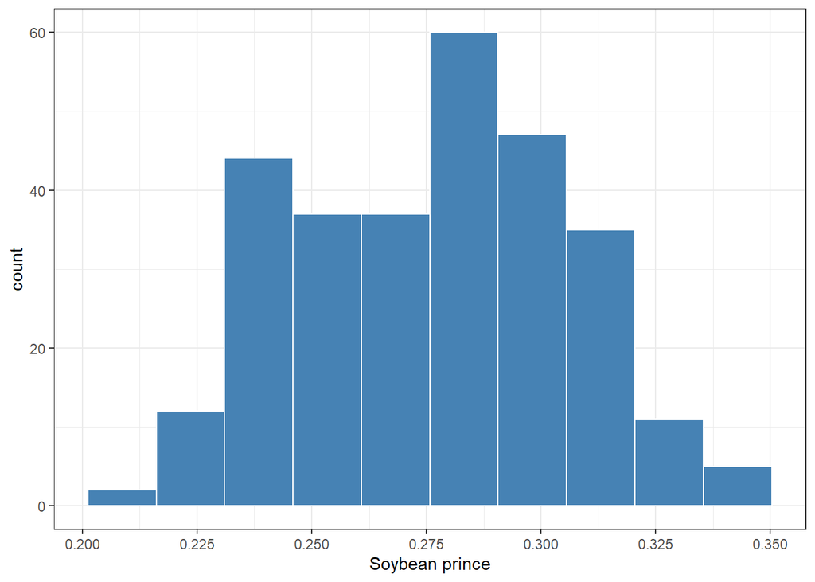

```r
sbr_price %>%
  ggplot(aes(price))+
  geom_histogram(bins = 10, fill = "steelblue", color = "white")+
  theme_bw()+
  labs(x = "Soybean prince")+
  scale_x_continuous(breaks = seq(0,1,by=0.025))
```

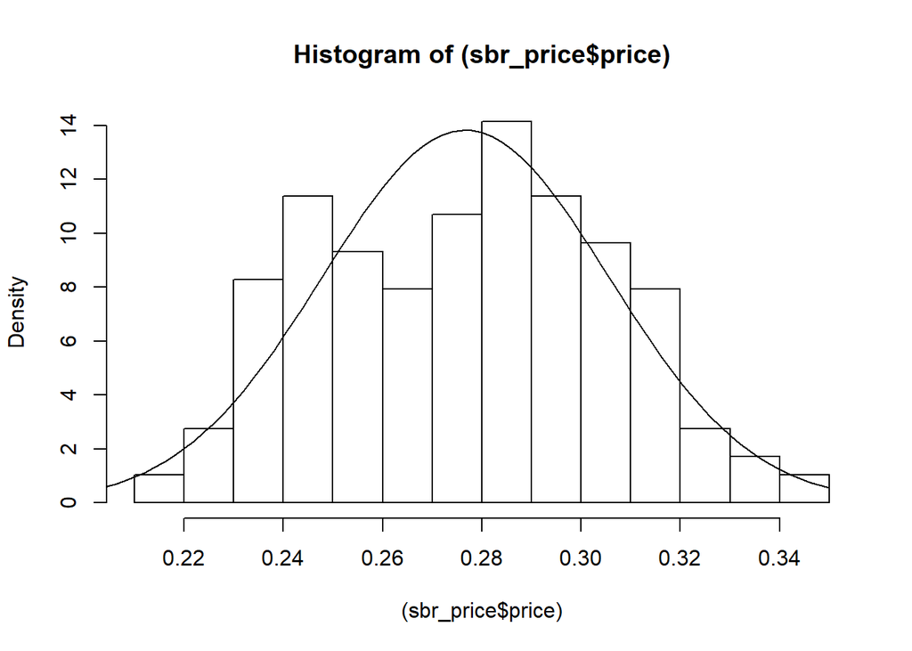

```r
hist((sbr_price$price), prob = T)
curve(dnorm(x, mean(sbr_price$price), sd(sbr_price$price)),0.15,0.35, add = T)
```

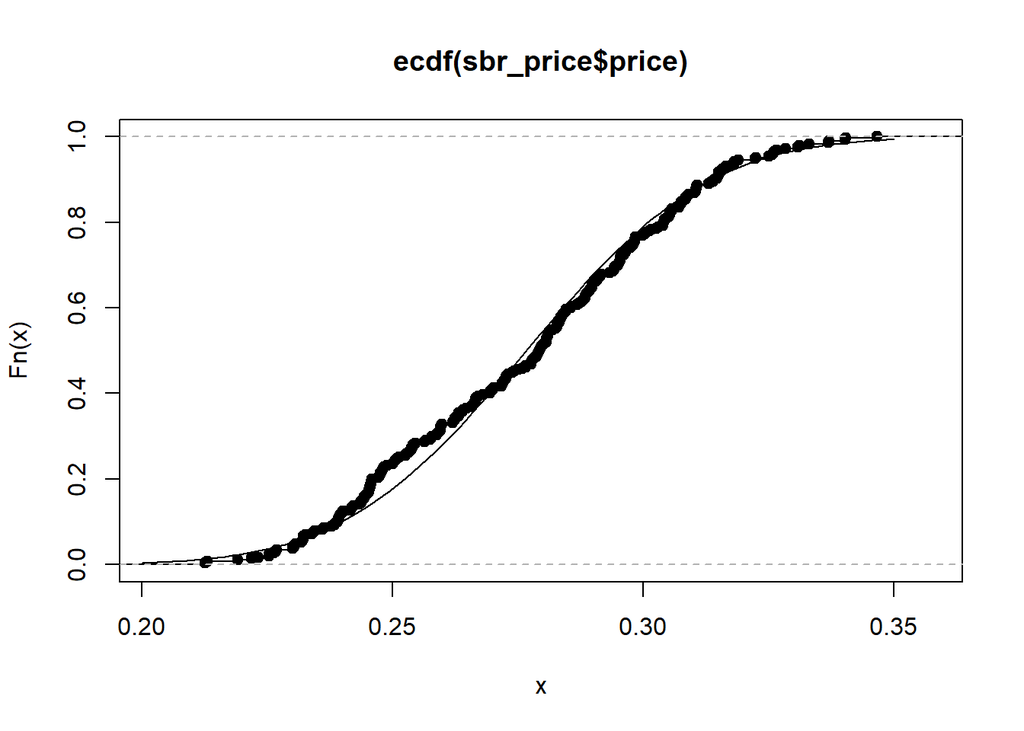

```r
plot(ecdf(sbr_price$price))
curve(pnorm(x, mean(sbr_price$price), sd(sbr_price$price)),0.2,0.35, add = T)
```

Mean and median

```r
mean(sbr_price$price)
```

```
## [1] 0.2766872
```

```r
median(sbr_price$price)
```

```
## [1] 0.2794258
```

## Vizualization

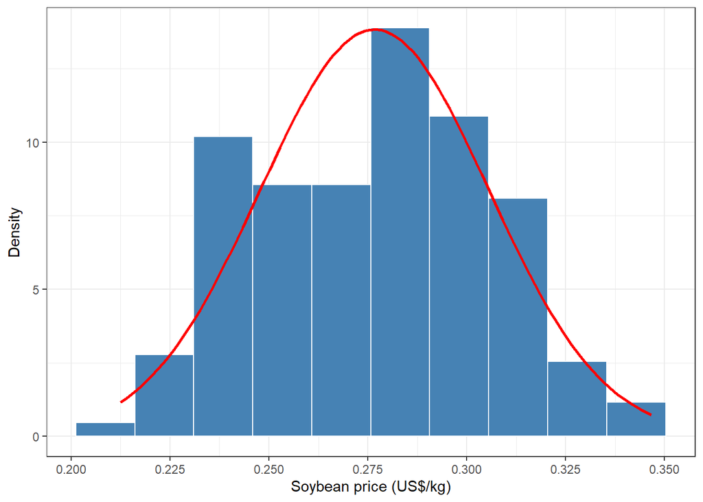

```r
price_plot = sbr_price %>%
  ggplot(aes(price))+
 geom_histogram(aes(y = ..density..),bins = 10, color = "white", fill = "Steelblue")+
   stat_function(fun=function(x) dnorm(x, mean(sbr_price$price), sd(sbr_price$price)), color= "red", size = 1)+
  theme_bw()+
  labs(x="Soybean price (US$/kg)", y = "Density")+
  scale_x_continuous(breaks = seq(0,1,by=0.025))
price_plot
```

```r
ggsave("figs/sev_dist.png", dpi=600, height = 3, width = 4)
```

# Regression coeficients

## import data

Importing regression Slope and intercept data from the relationship between SBR severity and yield

```r
damage_data = read_excel("dados histograma.xlsx") %>%
  mutate(Slope = b1,
         Intercept = b0) %>%
  select(-b1,-b0)
head(damage_data)
```

```
## # A tibble: 6 x 3
##   ensaio  Slope Intercept
##    <dbl>  <dbl>     <dbl>
## 1      1 -27.4      3197.
## 2      2  -5.89     2132.
## 3      3 -13.0      2729.
## 4      5 -23.0      2483.
## 5      6  -8.45     2790.
## 6      9 -30.6      2612.
```

## Empirical distribution

Visualizando os hitogramas do slope e intercepto

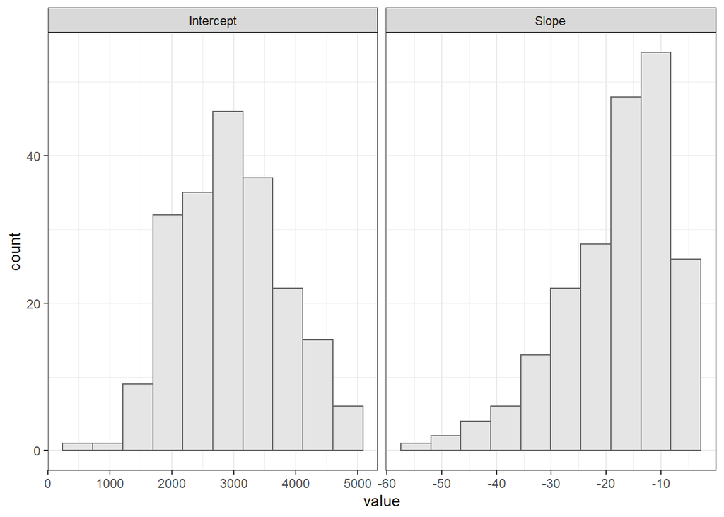

```r
damage_data %>%
  gather(2:3, key = "par", value = "value") %>%
  ggplot(aes(value))+
  geom_histogram(bins = 10, color = "gray40", fill = "gray90")+
  facet_wrap(~par, scales = "free_x")+
  theme_bw()
```

## Regression lines

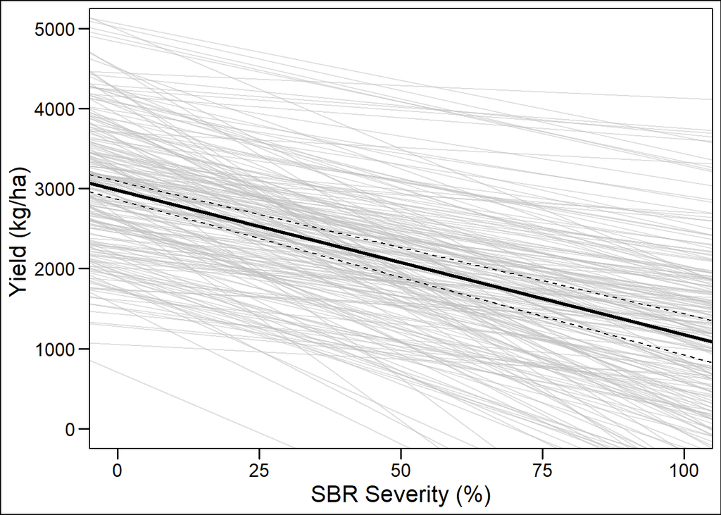

```r
  ggplot() +
  geom_point(aes(x = 0:100, y = seq(0,5000,by = 50)), color = NA)+
  geom_abline(data =damage_data, aes(slope = Slope, intercept = Intercept),
              alpha = 0.5, color = "gray")+
  geom_abline(intercept = 2977,slope = -18, size = 1.2)+
  geom_abline(intercept = 2862,slope = -19.4 , size = .51, linetype = 2)+
  geom_abline(intercept = 3093,slope = -16.6, size = .51, linetype = 2)+

  labs(x = "SBR Severity (%)", y = "Yield (kg/ha) ")+
  theme_base()
```

## correlation

Correlation between slope and intercept

```r
correlation(damage_data$Slope, damage_data$Intercept)
```

```
##
## Pearson's product-moment correlation
##
## data: damage_data$Slope and damage_data$Intercept
## t = -3.144296 , df = 202 , p-value = 0.001915808
## alternative hypothesis: true rho is not equal to 0
## sample estimates:
## cor
##  -0.2160089
```

Visualizing correlation

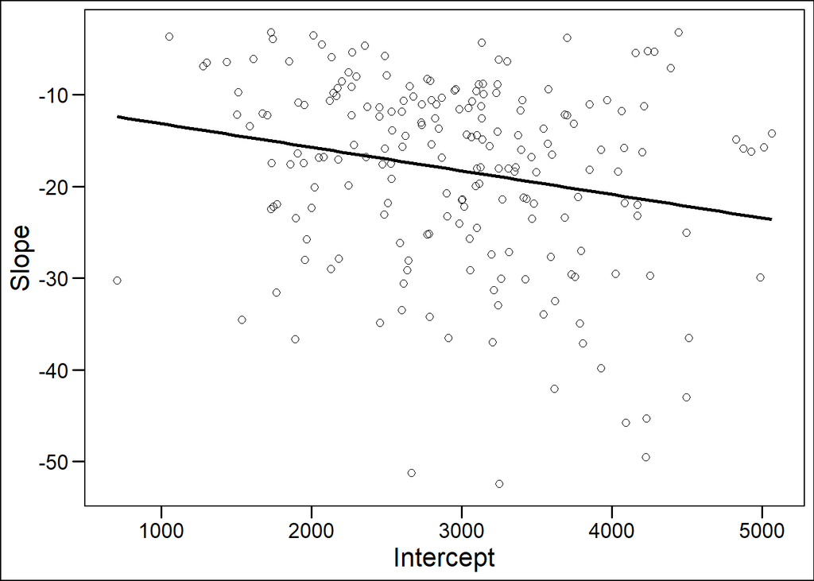

```r
damage_data %>%
  ggplot(aes(Intercept, Slope))+
  geom_point(shape =1, size =2)+
  geom_smooth(method = "lm", se = F, color ="black")+
  theme_base()
```

## Cumulative density

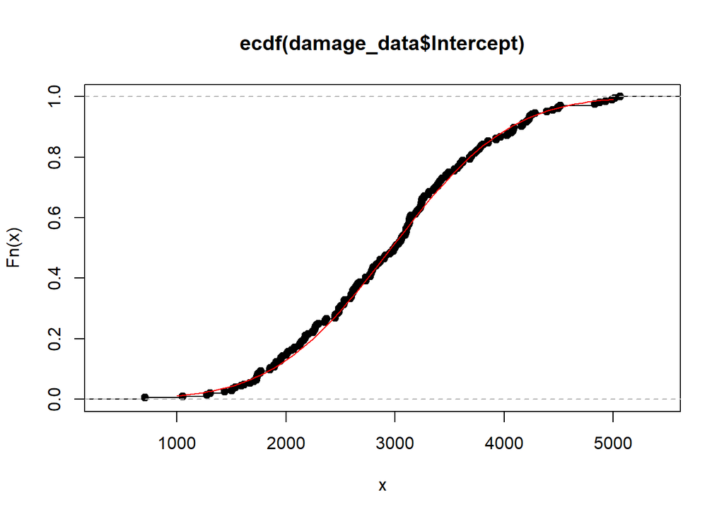

```r
mean_intercept = mean(damage_data$Intercept)
sd_intercept = sd(damage_data$Intercept)

plot(ecdf(damage_data$Intercept))
curve(pnorm(x, mean_intercept,sd_intercept), 1000,5000, add = T, col = "red")
```

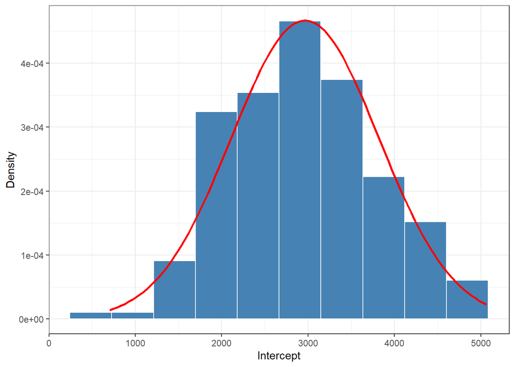

```r
intercep_plot = damage_data %>%
  ggplot(aes(Intercept))+
  geom_histogram(aes(y = ..density..),bins = 10, color = "white", fill = "steelblue")+
  stat_function(fun=function(x) dnorm(x, mean_intercept, sd_intercept), color ="red", size =1)+
  theme_bw()+
  labs(x="Intercept", y = "Density")
intercep_plot
```

### Slope

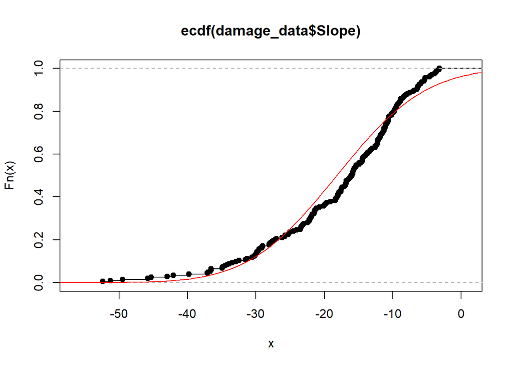

```r
mean_slope = mean(damage_data$Slope)
sd_slope = sd(damage_data$Slope)

plot(ecdf(damage_data$Slope))
curve(pnorm(x, mean_slope, sd_slope), -60,5, add = T, col = "red")
```

## Modeling

Fitting gamma distribution to the empirical cumulative density of the slope data

```r
Fx =environment(ecdf(-damage_data$Slope))$y
x = environment(ecdf(-damage_data$Slope))$x

slope_reg = nlsLM(Fx ~ pgamma(x, shape, rate,log = FALSE) ,
      start = c(shape = 2.5, rate = 0.13),
      control = nls.lm.control(maxiter = 1024))
summary(slope_reg)
```

```
##
## Formula: Fx ~ pgamma(x, shape, rate, log = FALSE)
##
## Parameters:
##       Estimate Std. Error t value Pr(>|t|)
## shape 3.044261   0.031275   97.34   <2e-16 ***
## rate  0.168269   0.001929   87.22   <2e-16 ***
## ---
## Signif. codes:  0 '***' 0.001 '**' 0.01 '*' 0.05 '.' 0.1 ' ' 1
##
## Residual standard error: 0.014 on 201 degrees of freedom
##
## Number of iterations to convergence: 4
## Achieved convergence tolerance: 1.49e-08
```

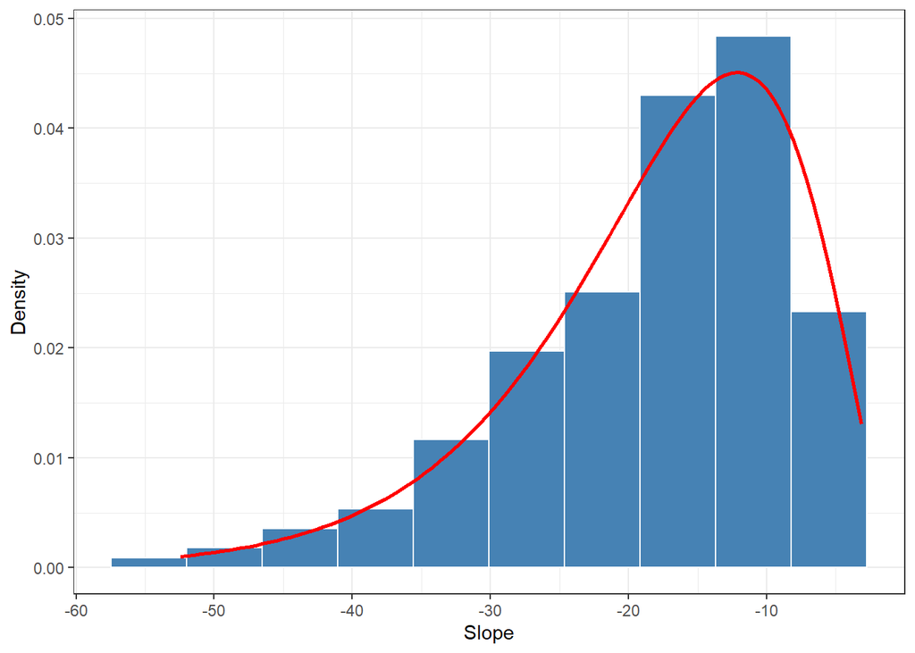

```r
shape = summary(slope_reg)$coef[1]
rate = summary(slope_reg)$coef[2]

slope_plot = damage_data %>%
  ggplot(aes(Slope))+
 geom_histogram(aes(y = ..density..),bins = 10, color = "white", fill = "steelblue")+
   stat_function(fun=function(x) dgamma(-x, shape, rate), size = 1, color = "red")+
  theme_bw()+
  labs(x="Slope", y = "Density")
slope_plot
```

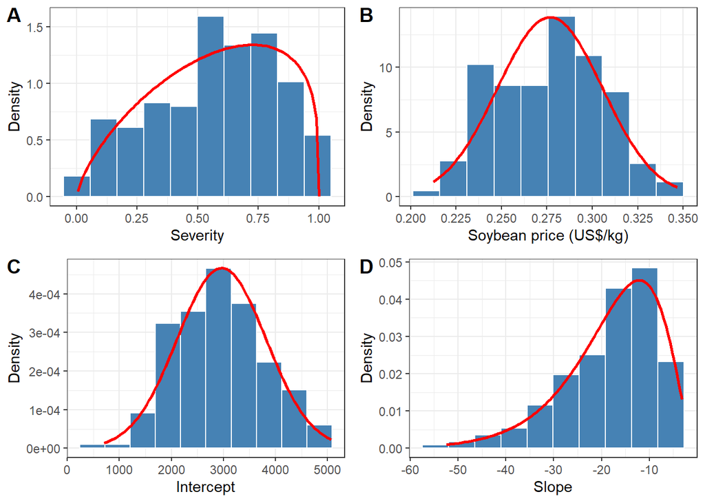

```r
plot_grid(sev_dist_plot,price_plot, intercep_plot, slope_plot, labels = "AUTO", nrow =2)
```

```r
ggsave("figs/coef_dist.png", dpi = 600, height = 6, width = 9)
```

# Multivariate Simulation using copula

```r
######################################
gera.norm.bid.geral<-function(tamanho.amostra,correlacao,m1,m2,sigma1,sigma2)
{
  ro<-correlacao
  n<-tamanho.amostra
  x<-matrix(0,n,2)
  for (i in 1:n)
  {x[i,1]<-rnorm(1,m1,sigma1)
  x[i,2]<-rnorm(1,m2+ro*sigma1/sigma2*(x[i,1]-m1),sigma2*(sqrt(1-ro^2)))
  }
  return(x)
}
```

Test for correlation of 0.9

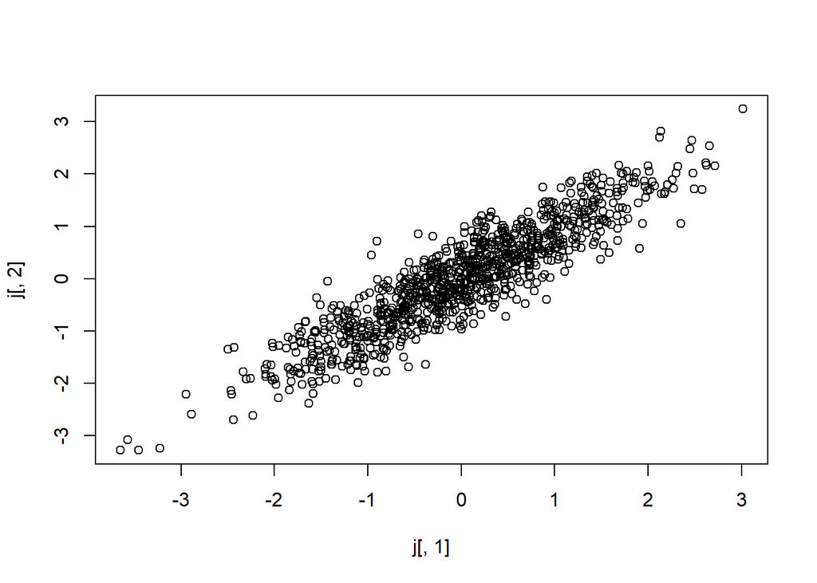

```r
#testando
j<-gera.norm.bid.geral(1000,0.9,0,0,1,1)

plot(j[,1],j[,2])
```

For our data, we will use the positive correlation, becouse we want positive values of slope

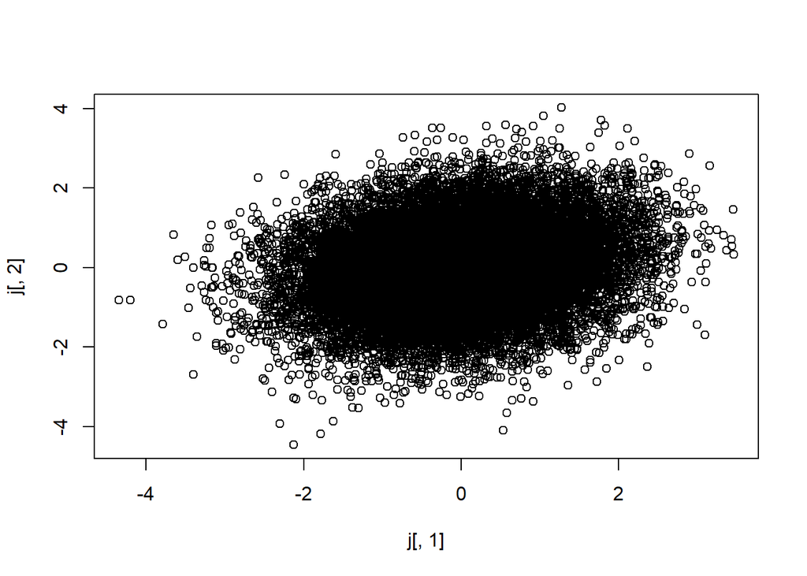

```r
#testando
j<-gera.norm.bid.geral(20000,0.21,0,0,1,1)

plot(j[,1],j[,2])
```

## Intercept

Now we obtaing the probabilities from first distribution and insert in the quantiles function for the normal distribution of the intercept

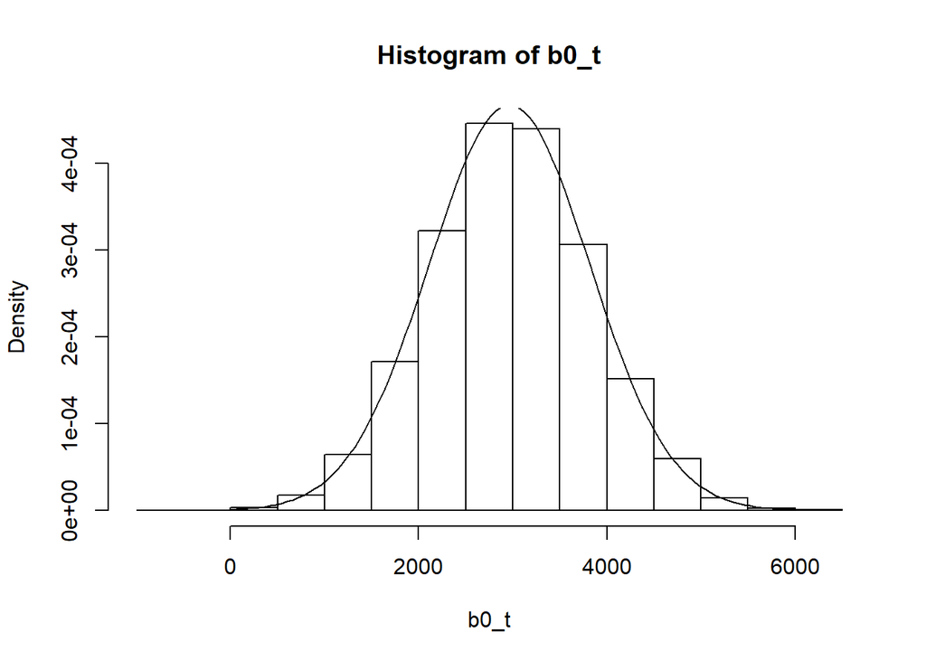

```r
b0 = pnorm(j[,2])
b0_t = qnorm(b0, 2977, 58.9*sqrt(210))
hist(b0_t, prob = T)
curve(dnorm(x, mean_intercept, sd_intercept), 0, 6000, add = T)
```

## Slope

Now we obtaing the probabilities from first distribution and insert in the quantiles function for the gamma ditribution and multiply for -1 for obtain the negative outputs of the coeficient

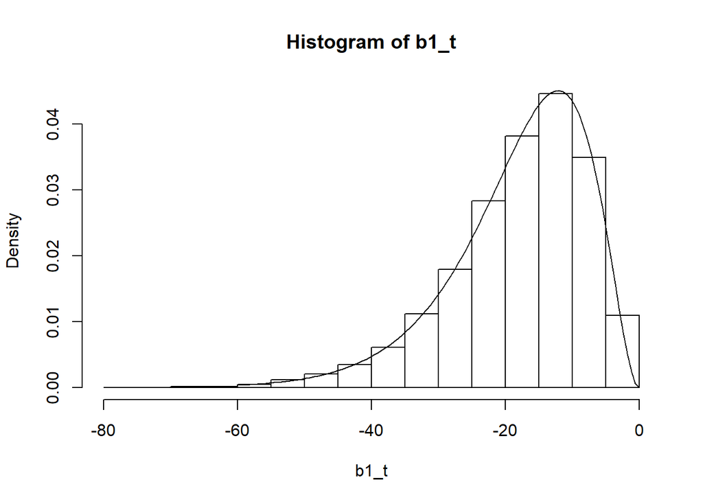

```r
b1 = pnorm(j[,1])
b1_t = qgamma(b1, shape, rate = rate)*-1
hist(b1_t, prob = T)
curve(dgamma(-x,shape=shape, rate = rate), -60,0, add = T)
```

Now we recalculate the correlation between the simulated coeficients. It matchs!

```r
correlation(b1_t, b0_t)
```

```
##
## Pearson's product-moment correlation
##
## data: b1_t and b0_t
## t = -29.30565 , df = 19998 , p-value = 0
## alternative hypothesis: true rho is not equal to 0
## sample estimates:
## cor
##  -0.2029212
```

Vizualizing the correlation

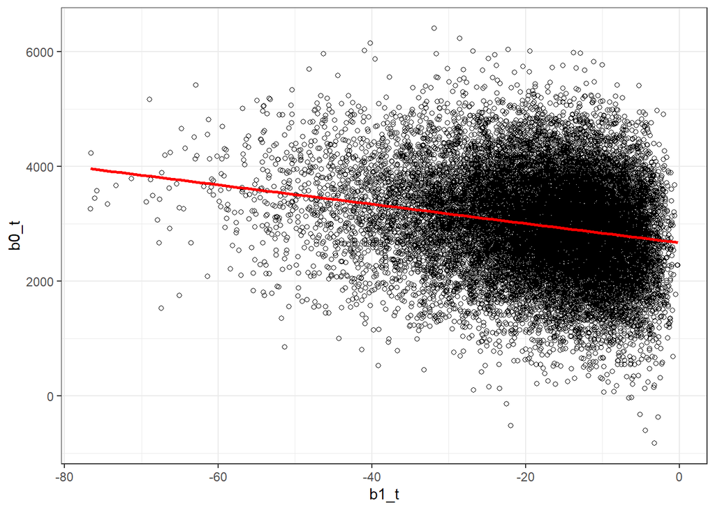

```r
ggplot()+
  geom_point(aes(b1_t, b0_t), shape =1)+
  geom_smooth(method = lm,
              aes(b1_t, b0_t), color = "red", se = F)+
  theme_bw()
```

## Relative yield loss

Here we calculate the yield relative loss due to SBR severirity using the original data set

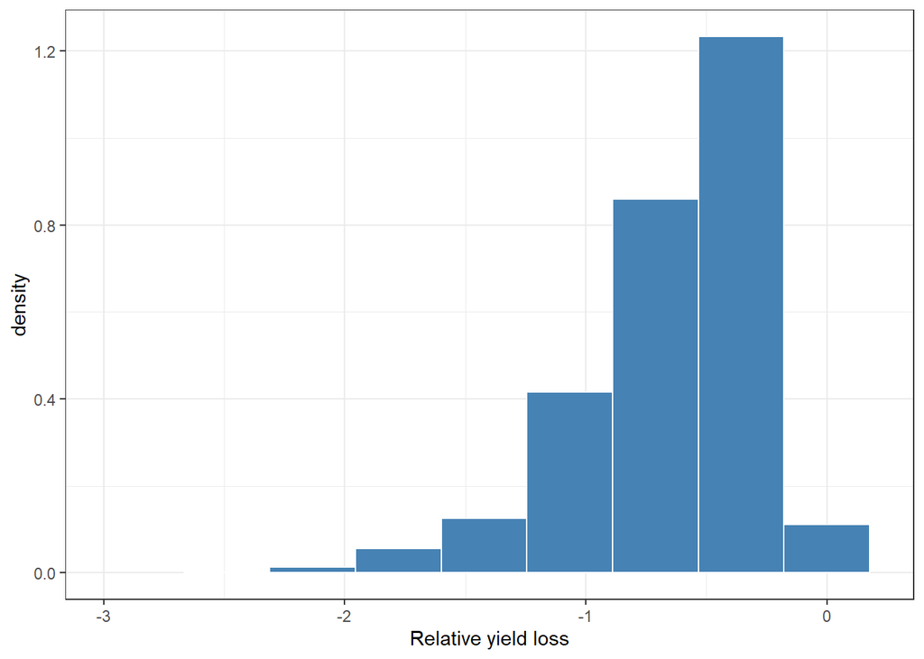

```r
real_RYL = damage_data %>%
  mutate(cc = (Slope/Intercept)*100) %>%
  filter( cc > -3 & cc <0 ) %>%
  ggplot(aes(cc))+
 geom_histogram(aes(y = ..density..),bins = 10, color = "white", fill = "Steelblue")+
# geom_histogram(color ="white", fill = "steelblue", bins = 20)+
  theme_bw()+
  labs(x = "Relative yield loss")+
  xlim(-3,0.2)
real_RYL
```

And here we calculate the relative yield loss due to SBR severirity using the simulated data set

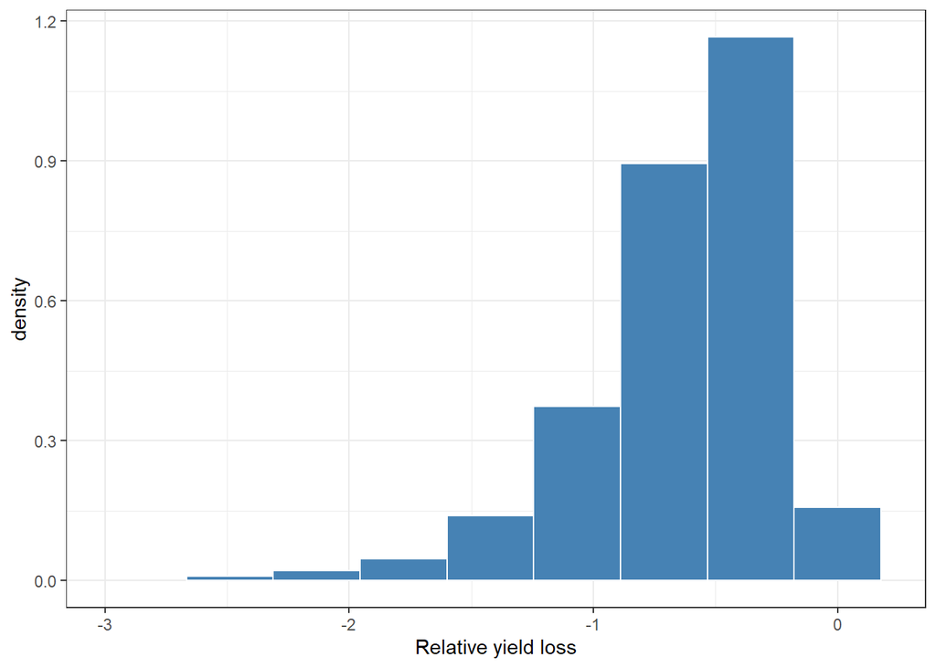

```r
simul_RYL = data.frame(b0_t, b1_t, cc = (b1_t/b0_t)*100) %>%
  filter( cc > -3 & cc <0 ) %>%
  ggplot(aes(cc))+
 geom_histogram(aes(y = ..density..),bins = 10, color = "white", fill = "Steelblue")+
# geom_histogram(color ="white", fill = "steelblue", bins = 20)+
  theme_bw()+
  labs(x = "Relative yield loss")+
  xlim(-3,0.2)
simul_RYL
```

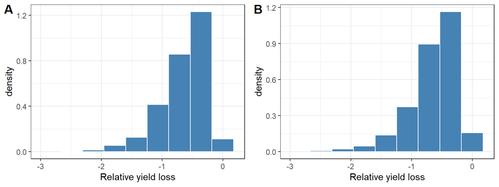

```r
plot_grid(real_RYL, simul_RYL, labels = "AUTO")
```

```r
ggsave("figs/RYL.png", dpi = 600, height = 3, width = 7)
```

### Comparision of mean, median and variance

```r
damage_data %>%
  mutate(cc = (Slope/Intercept)*100) %>%
  filter( cc > -2.5 & cc <0 ) %>%
  summarise(data = "empirical",
            mean =  mean(cc),
            median =  median(cc),
            variance = var(cc)) %>%
  bind_rows(
    data.frame(b0_t, b1_t, cc = (b1_t/b0_t)*100) %>%
  filter( cc > -2.5 & cc <0 ) %>%
  summarise(data = "Simulated",
            mean =  mean(cc),
            median =  median(cc),
            variance = var(cc))
  )
```

```
## # A tibble: 2 x 4
##   data        mean median variance
##   <chr>      <dbl>  <dbl>    <dbl>
## 1 empirical -0.637 -0.548    0.136
## 2 Simulated -0.636 -0.557    0.147
```

# Simulations

```r
n=10000
lambda = seq(0,1, by=0.05)
fun_price = seq(-10, 260, by=15)
n_aplication = 1
operational_cost = 10

comb_matrix = as.matrix(data.table::CJ(lambda,fun_price))
colnames(comb_matrix) = c("lambda","fun_price")
comb_matrix = cbind(comb_matrix,operational_cost, n_aplication)
C = comb_matrix[,"n_aplication"]*(comb_matrix[,"operational_cost"]+comb_matrix[,"fun_price"] )
comb_matrix = cbind(comb_matrix,C)

N = length(comb_matrix[,1])*n
big_one = matrix(0, ncol = 12, nrow =N)
big_one[,1] = rep(comb_matrix[,1],n)
big_one[,2] = rep(comb_matrix[,2],n)
big_one[,3] = rep(comb_matrix[,3],n)
big_one[,4] = rep(comb_matrix[,4],n)
big_one[,5] = rep(comb_matrix[,5],n)

sn = rbeta(N, 1.707, 1.266)
sf = sn*(1-big_one[,1])
# simulating the coeficientes  ###########
normal_correlated<-gera.norm.bid.geral(N,0.21,0,0,1,1)
b0_n = pnorm(normal_correlated[,2])
b1_n = pnorm(normal_correlated[,1])
b0 = qnorm(b0_n, mean_intercept,sd_intercept)
b1 = -qgamma(b1_n, shape, rate,)
rm(b0_n,b1_n,normal_correlated)
# b0[b0<0] = 0.0001
# Calculating the alha coeficient
alfa = (b1/b0)*100
# # alfa[alfa > 0] = 0
# alfa[alfa < -3] = -3

# Calculating yield gain
# yn = b0*(1+sn*alfa) # Yield  non-treated
# yf = b0*(1+sf*alfa) # Yield  treated
yn  = b0 - (-alfa*b0*sn)
yf  = b0 - (-alfa*b0*sf)
# yn[yn<0] = 0
# yf[yf<0] = 0
# yield_gain = yf-yn # yield gain
# yield_gain_perc = (1-(yn/yf))*100
########################################
# Simulating soybean price
soy_price = rnorm(N, mean(sbr_price$price),sd(sbr_price$price))
# income = yield_gain*soy_price # calculating the income

big_one[,6] = yn
big_one[,7] = yf
big_one[,8] = soy_price
big_one[,9] = b1
big_one[,10] = alfa
big_one[,11] = b0
big_one[,12] = sn
colnames(big_one)  = c("lambda","fun_price","operational_cost","n_aplication","C","yn","yf","soy_price","b1","alfa","b0", "sn")
```

```r
big_one_df = as.data.frame(big_one) %>%
  filter(b0>=0) %>%
  filter(yn>0) %>%
  filter(alfa > -3 & alfa < 0) %>%
  mutate(yield_gain = yf-yn,
         # yield_gain_perc = ((yf - yn)/yn)*100,
         yield_gain_perc = ((yf/yn)-1)*100,
         income = yield_gain*soy_price,
         CP = C/soy_price,
         profit = (yield_gain>=CP)*1)
```

## plot 1

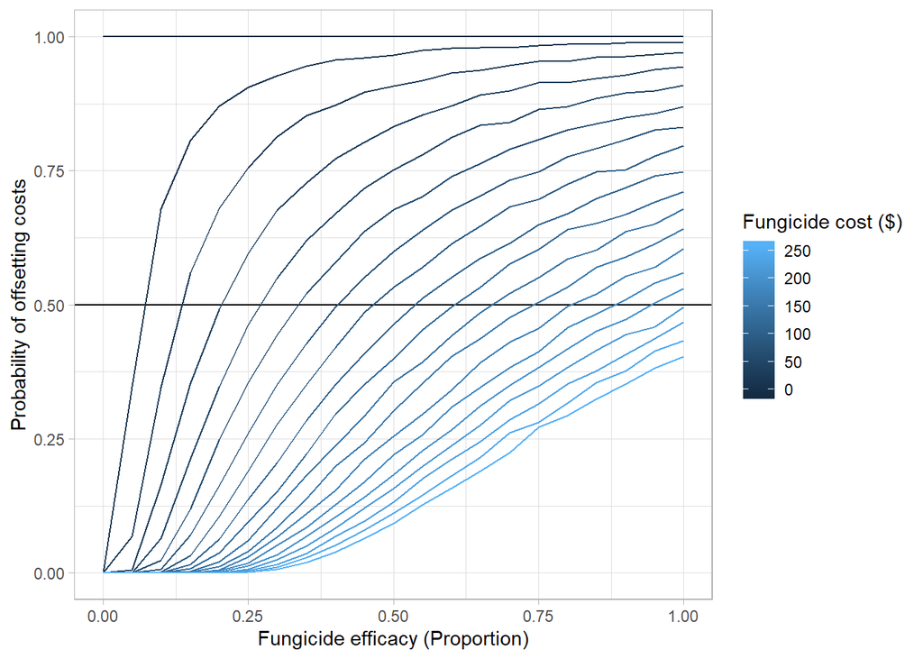

```r
big_one_df %>%
  group_by(lambda, C) %>%
  summarise(n=n(),sumn = sum(profit), prob = sumn/n) %>%
  ggplot(aes(lambda, prob, group =factor((C/n_aplication)-10), color = ((C/n_aplication)-10)))+
  geom_hline(yintercept = 0.5)+
  geom_line()+
  labs(x = "Fungicide efficacy (Proportion)",
       y = "Probability of offsetting costs",
       color  = "Fungicide cost ($)")+
  theme_light()
```

```r
ggsave("figs/curves.png", dpi = 600, height = 3, width = 6)
```

## Tetris

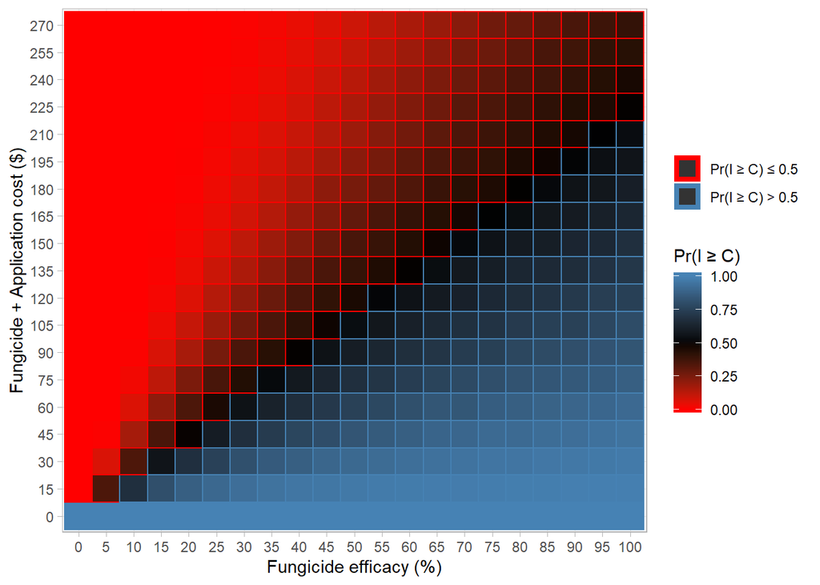

```r
big_one_df %>%
  # mutate(sev_class = case_when(sn > median(sn) ~ "High severity",
                                 # sn <= median(sn) ~ "Low severity")) %>%
  group_by(lambda, C) %>%
  summarise(n=n(),sumn = sum(profit), prob = sumn/n) %>%
  # filter(prob>0.5) %>%
  mutate(prob2 = case_when(prob < 0.50 ~ "Pr(I \u2265 C) \u2264 0.5 ",
                          prob >= 0.50 ~ "Pr(I \u2265 C) > 0.5")) %>% #,
  # #                         prob >= 0.75 ~ "75% \u2264 p < 100% "  )) %>%
  ggplot(aes(as.factor(lambda*100),as.factor(C), fill = prob, color = prob2))+
  geom_tile(size = 0.5)+
  # scale_fill_viridis_d()+
  # scale_fill_manual(values = c("darkred",  "steelblue"))+
  scale_fill_gradient2(low = "red",mid = "black", high = "steelblue",midpoint = 0.5)+
  scale_color_manual(values = c("red","steelblue")) +
  guides(color = guide_legend(override.aes = list(size=2)))+
  # scale_fill_viridis_d(option = "B")+
  labs(x = "Fungicide efficacy (%)",
       y = "Fungicide + Application cost ($)",
       fill  = "Pr(I \u2265 C)",
       color ="" )+
  # facet_wrap(~sev_class)+
  theme_light()
```

```r
ggsave("figs/tetris.png", dpi = 600, height = 5, width = 7)
```

## Tetris 2

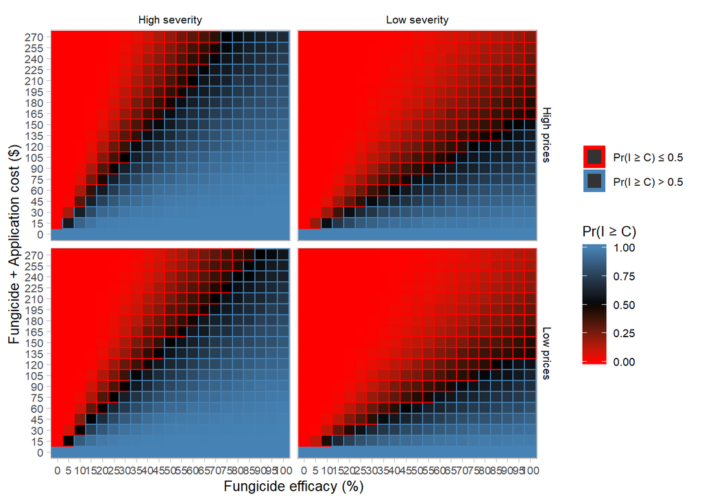

```r
big_one_df %>%
  mutate(sev_class = case_when(sn > median(sn) ~ "High severity",
                                 sn <= median(sn) ~ "Low severity")) %>%
  mutate(price_class = case_when(soy_price > median(soy_price) ~ "High prices",
                                soy_price <= median(soy_price) ~ "Low prices")) %>%
  group_by(lambda, C,sev_class,price_class) %>%
  summarise(n=n(),sumn = sum(profit), prob = sumn/n) %>%

  mutate(prob2 = case_when(prob < 0.50 ~ "Pr(I \u2265 C) \u2264 0.5 ",
                          prob >= 0.50 ~ "Pr(I \u2265 C) > 0.5")) %>% #,
  ggplot(aes(as.factor(lambda*100),as.factor(C), fill = prob, color = prob2))+
  geom_tile(size = 0.5)+
  scale_fill_gradient2(low = "red",mid = "black", high = "steelblue",midpoint = 0.5)+
  scale_color_manual(values = c("red","steelblue")) +
  labs(x = "Fungicide efficacy (%)",
       y = "Fungicide + Application cost ($)",
       fill  = "Pr(I \u2265 C)",
       color ="" )+
  facet_grid(price_class~sev_class)+
  guides(color = guide_legend(override.aes = list(size=2)))+
  theme_light()+
  theme(text = element_text(size = 10),
        strip.background =element_rect(fill="NA"),
        strip.text = element_text(color = "black"))
```

```r
ggsave("figs/tetris_facet.png", dpi = 600, height = 6.5, width = 9)
```

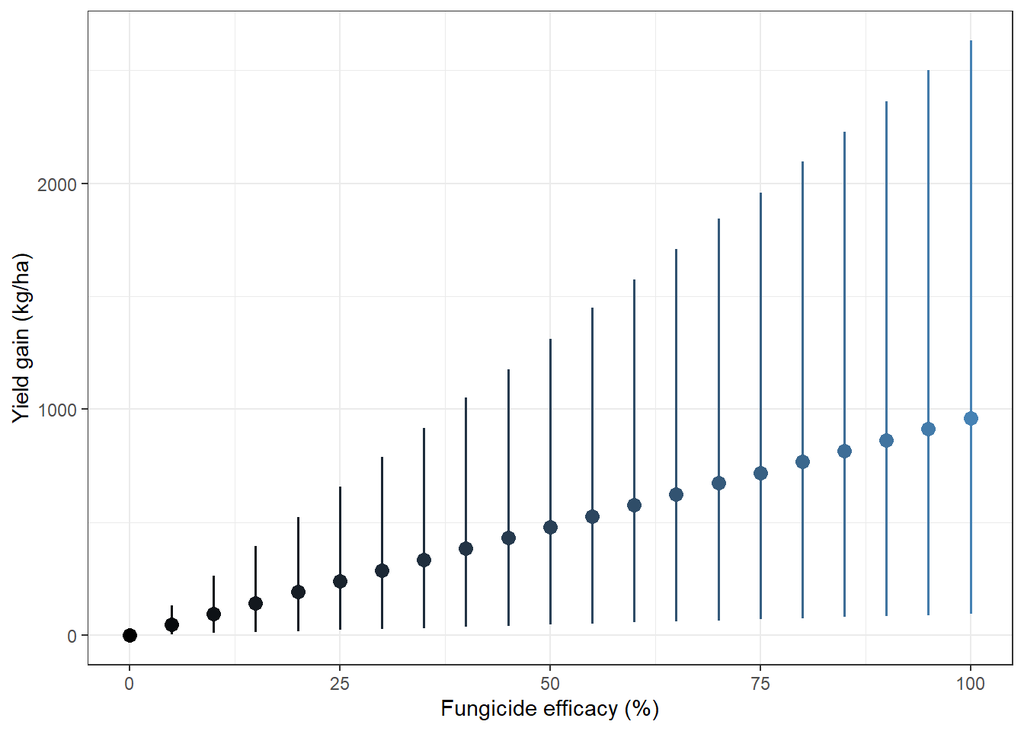

```r
big_one_df %>%
  group_by(lambda ) %>%
  summarise(yield_gain_m = mean(yield_gain),
            up = quantile(yield_gain, 0.975),
            low = quantile(yield_gain, 0.025)) %>%
  ggplot(aes(lambda*100,yield_gain_m, color = yield_gain_m))+
  geom_point(size = 3)+
  geom_errorbar(aes(ymin = low, ymax = up), size = 0.7, width = 0)+
  scale_color_gradient(low = "black", high = "steelblue")+
  theme_bw()+
  labs(x = "Fungicide efficacy (%)",
       y = "Yield gain (kg/ha)")+
  theme(legend.position = "none")
```

```r
# ggsave("figs/yield_gain.png", dpi = 600, height = 4, width = 6)
```

## Yield gain

```r
fun = c("BIXF + TRIF + PROT","AZOX + BENZ","PYRA + EPOX + FLUX","TFLX + PROT","PYRA + FLUX","PICO + CYPR","AZOX + CYPR")
C = c(83.74,83.50,79.25,79.42,70.75,60.36,48.45)
C_L = c(79.56,80.08,74.48,76.11,66.49,56.10,43.22)
C_U = c(87.06,86.33,83.13,82.28,74.47,64.21,53.20)
D = c(1028.64,1006.42,943.77,893.7,814.69,594.34,437.84)
D_L = c(949.18,915.42,861.32,818.68, 741.7,533.92,386.33)
D_U = c(1108.10,1097.43,1026.23,968.7,887.58, 654.76,489.36)

dat = data.frame(fun, C,C_L,C_U,D,D_L,D_U)
```

```r
overal_yg = big_one_df %>%
  mutate(sev_class = "Overall") %>%
  group_by(lambda,sev_class) %>%
  summarise(yield_gain_median = median(yield_gain),
            yield_gain_mean = mean(yield_gain),
            up_95 = quantile(yield_gain, 0.975),
            low_95 = quantile(yield_gain, 0.025),
            up_75 = quantile(yield_gain, 0.75),
            low_75 = quantile(yield_gain, 0.25))
```

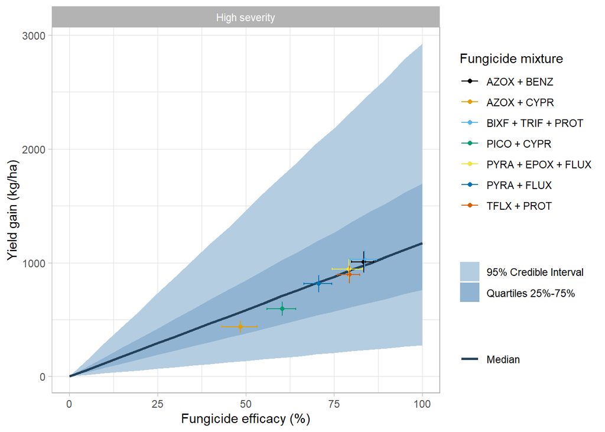

```r
y_gain = big_one_df %>%
  mutate(sev_class = case_when(sn > median(sn) ~ "High severity",
                                 sn <= median(sn) ~ "Low severity")) %>%
  group_by(lambda, sev_class ) %>%
  summarise(yield_gain_median = median(yield_gain),
            yield_gain_mean = mean(yield_gain),
            up_95 = quantile(yield_gain, 0.975),
            low_95 = quantile(yield_gain, 0.025),
            up_75 = quantile(yield_gain, 0.75),
            low_75 = quantile(yield_gain, 0.25)) %>%
  bind_rows(overal_yg) %>%
  mutate(sev_class = factor(sev_class, levels = c("Overall","Low severity","High severity"))) %>%
    filter(sev_class == "High severity") %>%
  ggplot(aes(lambda*100,yield_gain_median))+
  geom_ribbon(aes(ymin = low_95, ymax = up_95,fill = "95% Credible Interval"))+# ,alpha = .2)+
  geom_ribbon(aes(ymin = low_75, ymax = up_75, fill = "Quartiles 25%-75%"))+# ,alpha = .3)+
  geom_line(size = 1, color = "#23415a", aes(linetype = "Median"))+

  geom_point(data = dat, aes(C,D, color = fun))+
  geom_errorbar(data = dat, aes(C,D, ymin = D_L, ymax = D_U, color = fun))+
  geom_errorbarh(data = dat, aes(C,D, xmin = C_L, xmax = C_U, color = fun))+
  scale_color_colorblind()+
  scale_fill_manual(values = c("#b5cde0", "#90b4d2"))+
  facet_wrap(~sev_class)+
  theme_light()+
  labs(x = "Fungicide efficacy (%)",
       y = "Yield gain (kg/ha)",
       color = "Fungicide mixture",
       linetype = "", fill = "")+
  theme()
y_gain
```

```r
ggsave("figs/yield_gain2.png", dpi = 600, height = 6, width =8)
```

```r
big_one_df %>%
  mutate(sev_class = case_when(sn > median(sn) ~ "High severity",
                                 sn <= median(sn) ~ "Low severity")) %>%
  group_by(lambda, sev_class ) %>%
  summarise(yield_gain_median = median(yield_gain),
            # yield_gain_mean = mean(yield_gain),
            up_95 = quantile(yield_gain, 0.975),
            low_95 = quantile(yield_gain, 0.025),
            up_75 = quantile(yield_gain, 0.75),
            low_75 = quantile(yield_gain, 0.25)) %>%
  bind_rows(overal_yg)
```

```
## # A tibble: 63 x 8
## # Groups:   lambda [21]
##    lambda sev_class yield_gain_medi~ up_95 low_95 up_75 low_75
##     <dbl> <chr>                <dbl> <dbl>  <dbl> <dbl>  <dbl>
##  1   0    High sev~              0     0     0      0      0
##  2   0    Low seve~              0     0     0      0      0
##  3   0.05 High sev~             58.5 145.   13.7   84.6   38.1
##  4   0.05 Low seve~             26.4  90.7   3.08  43.3   14.5
##  5   0.1  High sev~            118.  293.   27.7  169.    76.4
##  6   0.1  Low seve~             53.1 181.    6.32  87.2   29.1
##  7   0.15 High sev~            175.  437.   41.2  254.   114.
##  8   0.15 Low seve~             79.0 272.    9.34 130.    43.4
##  9   0.2  High sev~            234.  580.   54.9  338.   152.
## 10   0.2  Low seve~            105.  365.   12.3  174.    57.9
## # ... with 53 more rows, and 1 more variable: yield_gain_mean <dbl>
```

## Yield gain percent

```r
overal_percet = big_one_df %>%
  mutate(sev_class = "Overall") %>%
  group_by(lambda,sev_class) %>%
  summarise(yield_gain_median = median(yield_gain_perc,na.rm = T),
            yield_gain_mean = mean(yield_gain_perc,na.rm = T),
            up_95 = quantile(yield_gain_perc, 0.975,na.rm = T),
            low_95 = quantile(yield_gain_perc, 0.025,na.rm = T),
            up_75 = quantile(yield_gain_perc, 0.75,na.rm = T),
            low_75 = quantile(yield_gain_perc, 0.25,na.rm = T))
```

```r
fun = c("AZOX","CYPR","TEBU","AZOX+CYPR","PICO+CYPR","PYRA+EPOX","TRIF+PROT")
C = c(61.8,55.8,57.8,79.0,80.2,76.7,83.6)
C_L = c(57.7,52.11,54.5,76.5,77.6,73.7,81.4)
C_U = c(NA, 59.2,60.9,81.4,82.5,79.4,85.6)

D = c(29.6,27.7,29.6,49.2,51.1,47.2,64.8)
D_L = c(25.2,24.2,26.3,43.6,45.1,41.6,57.2)
D_U = c(NA,31.3,33.1,55.2,57.4,53,72.8)

dat2 = data.frame(fun, C,C_L,C_U,D,D_L,D_U)
```

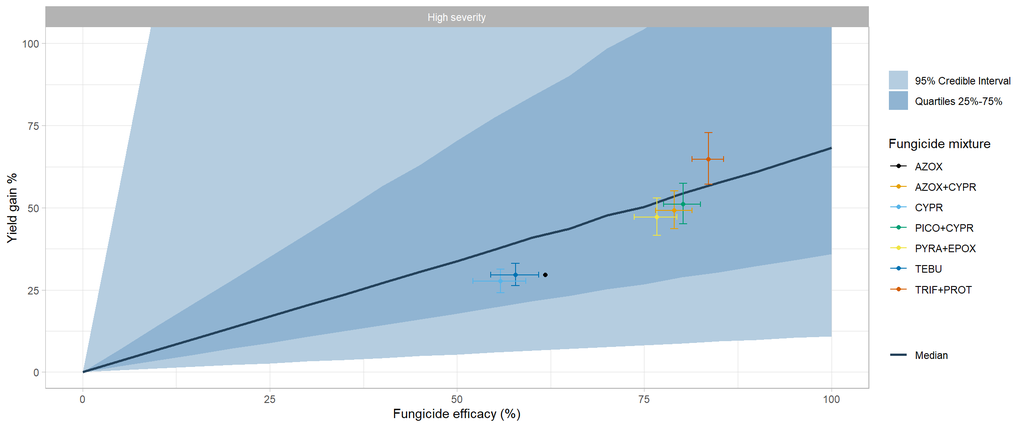

```r
y_gain_perc = big_one_df %>%
  mutate(sev_class = case_when(sn > median(sn) ~ "High severity",
                                 sn <= median(sn) ~ "Low severity")) %>%
  group_by(lambda,sev_class) %>%
  summarise(yield_gain_median = median(yield_gain_perc,na.rm = T),
            yield_gain_mean = mean(yield_gain_perc,na.rm = T),
            up_95 = quantile(yield_gain_perc, 0.975,na.rm = T),
            low_95 = quantile(yield_gain_perc, 0.025,na.rm = T),
            up_75 = quantile(yield_gain_perc, 0.75,na.rm = T),
            low_75 = quantile(yield_gain_perc, 0.25,na.rm = T)) %>%
  bind_rows(overal_percet) %>%
  mutate(sev_class = factor(sev_class, levels = c("Overall","Low severity","High severity"))) %>%
  filter(sev_class == "High severity") %>%
  ggplot(aes(lambda*100,yield_gain_mean))+
  geom_ribbon(aes(ymin = low_95, ymax = up_95,fill = "95% Credible Interval"))+# ,alpha = .2)+
  geom_ribbon(aes(ymin = low_75, ymax = up_75, fill = "Quartiles 25%-75%"))+# ,alpha = .3)+
  # geom_line(size = 0.5, color = "black", aes(linetype = "Simulated mean"))+
  geom_line(size = 1, color = "#23415a",aes(lambda*100,yield_gain_median,linetype = "Median" ))+


  geom_point(data = dat2, aes(C,D, color = fun))+
  geom_errorbar(data = dat2, aes(C,D, ymin = D_L, ymax = D_U, color = fun))+
  geom_errorbarh(data = dat2, aes(C,D, xmin = C_L, xmax = C_U, color = fun))+
  scale_fill_manual(values = c("#b5cde0", "#90b4d2"))+
  # scale_linetype_manual(values=c(1,2))+
  scale_color_colorblind()+
    facet_wrap(~sev_class)+
  theme_light()+
  # coord_equal()+
  labs(x = "Fungicide efficacy (%)",
       y = "Yield gain %",
       color = "Fungicide mixture", #(Dalla lana et al., 2018)
       linetype = "", fill = "")+
  coord_cartesian(ylim = c(0,100))
y_gain_perc
```

```r
    ggsave("figs/yield_gain_perc.png", dpi = 600, height = 6, width =8)
 big_one_df %>%
  mutate(sev_class = case_when(sn > median(sn) ~ "High severity",
                                 sn <= median(sn) ~ "Low severity")) %>%
  group_by(lambda,sev_class) %>%
  summarise(yield_gain_median = median((yield_gain_perc),na.rm = T),
            yield_gain_mean = mean((yield_gain_perc),na.rm = T),
            up_95 = quantile((yield_gain_perc), 0.975,na.rm = T),
            low_95 = quantile((yield_gain_perc), 0.025,na.rm = T),
            up_75 = quantile((yield_gain_perc), 0.75,na.rm = T),
            low_75 = quantile((yield_gain_perc), 0.25,na.rm = T)) %>%
  bind_rows(overal_percet)
```

```
## # A tibble: 63 x 8
## # Groups:   lambda [21]
##    lambda sev_class yield_gain_medi~ yield_gain_mean  up_95 low_95 up_75
##     <dbl> <chr>                <dbl>           <dbl>  <dbl>  <dbl> <dbl>
##  1   0    High sev~             0               0      0     0      0
##  2   0    Low seve~             0               0      0     0      0
##  3   0.05 High sev~             3.39           17.8   57.6   0.546  7.02
##  4   0.05 Low seve~             1.13            2.66   9.90  0.112  2.19
##  5   0.1  High sev~             6.83           30.3  115.    1.09  14.1
##  6   0.1  Low seve~             2.26            5.79  20.2   0.229  4.41
##  7   0.15 High sev~            10.2           145.   167.    1.63  21.2
##  8   0.15 Low seve~             3.38            8.20  30.4   0.339  6.57
##  9   0.2  High sev~            13.5           224.   225.    2.18  28.1
## 10   0.2  Low seve~             4.52           12.1   40.0   0.452  8.79
## # ... with 53 more rows, and 1 more variable: low_75 <dbl>
```